# Part 2: Starting to Play with Data

Playing with Python is *always* fun, but playing with data in Python is even more fun. So...

Let's get some data!

But first...

# Simplicity and import

- The developers of Python opted to keep Python fairly small, focused and simple.
- Adding new features is done by importing libraries.
  - Libraries extend the basic features of Python
  - Many libraries are installed by default (still need to be imported)
  - Others can be downloaded
- Most Python scripts require importing something

## Import

```python
import numpy
```

Importing a library is like getting a kitchen appliance out of a cabinet and setting it up on the counter--a mixer, for example.

Libraries provide additional functionality to the basic Python package, much like a new appliance adds functionality to the kitchen.

Just like in the kitchen, importing too many libraries can sometimes complicate and slow down your programs (*having the mixer, bread machine and pasta maker all out at once will make it harder to get things done in the kitchen*)- so we only import what we need for each program.

## Loading data

We will use the numpy module to load our data.

```python
data = numpy.loadtxt(fname='data/inflammation-01.csv', delimiter=',')
```

```python
print(data)
```

```
[[ 0.  0.  1. ...,  3.  0.  0.]
 [ 0.  1.  2. ...,  1.  0.  1.]
 [ 0.  1.  1. ...,  2.  1.  1.]
 ...,
 [ 0.  1.  1. ...,  1.  1.  1.]
 [ 0.  0.  0. ...,  0.  2.  0.]
 [ 0.  0.  1. ...,  1.  1.  0.]]
```

## About the data

We are studying inflammation in patients who have been given a new treatment for arthritis, and need to analyze the first dozen data sets of their daily inflammation. The data sets are stored in comma-separated values (CSV) format: each row holds information for a single patient, and the columns represent successive days. The first few rows of our first file look like this:

```
0,0,1,3,1,2,4,7,8,3,3,3,10,5,7,4,7,7,12,18,6,13,11,11,7,7,4,6,8,8,4,4,5,7,3,4,2,3,0,0
0,1,2,1,2,1,3,2,2,6,10,11,5,9,4,4,7,16,8,6,18,4,12,5,12,7,11,5,11,3,3,5,4,4,5,5,1,1,0,1
0,1,1,3,3,2,6,2,5,9,5,7,4,5,4,15,5,11,9,10,19,14,12,17,7,12,11,7,4,2,10,5,4,2,2,3,2,2,1,1
```

- We want to:
  - load that data into memory,
  - calculate the average inflammation per day across all patients, and plot the result.
  - To do all that, we’ll have to learn a little bit about programming.

## Indexes

[figure not shown]

```python
print(data[0][0])
```

```
0.0
```

```python
print(data[0][3])
```

```
3.0
```

## Exploring the data

We can get the mean (average) of the data with the mean function

```python
data.mean()
```

```
6.1487499999999997
```

## Min, Max, std

Note that we can assign values to multiple variables at once.

```python
maxval, minval, stdval = data.max(axis=None), data.min(axis=None), data.std(axis=None)
print('Maximum inflammation:', maxval)
print('Minimum inflammation:', minval)
print('Standard deviation:', stdval)
```

```
Maximum inflammation: 20.0
Minimum inflammation: 0.0
Standard deviation: 4.61383319712
```

## Analyze a single patient

```python
patient_C = data[2, :] # 2 on the first axis (rows), everything on the second (columns)
print('Maximum inflamation for patient C is:', patient_C.max())
```

```
Maximum inflamation for patient C is: 19.0
```

## Summarize across rows or columns

If we want to look at inflamation for each patient (row) or over days (columns) we can do that too.

[figure not shown]

```python
data.max(axis=1)
```

```
array([ 18.,  18.,  19.,  17.,  17.,  18.,  17.,  20.,  17.,  18.,  18.,
        18.,  17.,  16.,  17.,  18.,  19.,  19.,  17.,  19.,  19.,  16.,
        17.,  15.,  17.,  17.,  18.,  17.,  20.,  17.,  16.,  19.,  15.,
        15.,  19.,  17.,  16.,  17.,  19.,  16.,  18.,  19.,  16.,  19.,
        18.,  16.,  19.,  15.,  16.,  18.,  14.,  20.,  17.,  15.,  17.,
        16.,  17.,  19.,  18.,  18.])
```

```python
data.mean(axis=0)
```

```
array([  0.        ,   0.45      ,   1.11666667,   1.75      ,
         2.43333333,   3.15      ,   3.8       ,   3.88333333,
         5.23333333,   5.51666667,   5.95      ,   5.9       ,
         8.35      ,   7.73333333,   8.36666667,   9.5       ,
         9.58333333,  10.63333333,  11.56666667,  12.35      ,
        13.25      ,  11.96666667,  11.03333333,  10.16666667,
        10.        ,   8.66666667,   9.15      ,   7.25      ,
         7.33333333,   6.58333333,   6.06666667,   5.95      ,
         5.11666667,   3.6       ,   3.3       ,   3.56666667,
         2.48333333,   1.5       ,   1.13333333,   0.56666667])
```

# Visualizing data

The mathematician Richard Hamming once said,

> “The purpose of computing is insight, not numbers,” and the best way to develop insight is often to visualize data.

Visualization deserves an entire lecture of its own, but we can explore a few features of Python’s matplotlib library here. While there is no official plotting library, matplotlib is the de facto standard. First, we will import the pyplot module from matplotlib and use two of its functions to create and display a heat map of our data:

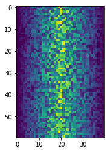

```python
%matplotlib inline
import matplotlib.pyplot
image = matplotlib.pyplot.imshow(data)
matplotlib.pyplot.show()
```

## Average inflamation over time

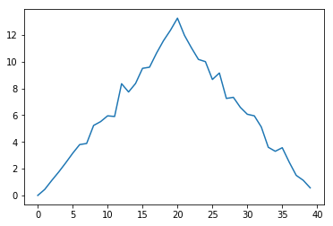

```python
ave_inflammation = data.mean(axis=0)
ave_plot = matplotlib.pyplot.plot(ave_inflammation)
matplotlib.pyplot.show()
```

## Next up: loops

Imagine that this is the data from one study. We've done a great job and turn this into our boss, who looks at the graphs and says:

> "That's great, here's 100 more datasets, make the same graph for each...By the end of the day!"

Now we need to learn about automation with loops!